# 452HW6

Huixin Blessia Li

2023-02-24

# Q1: PCA (Principal Component Analysis) is an unsupervised ML method that is often used to reduce dimensionality of large data sets.

## 1.1 Please explain how PCA can be used to reduce the number of variables.

PCA can be used to identify patterns in highly complex datasets and what variables in the data are the most important. The goal is to find a smaller set of variables that can explain the majority of the variability in the original data. To do that, we usually first standardize/scale the data, and then apply PCA to the standardized date. PCA finds the best fitting line by maximizing the sum of the squared distances from the projected points to the origin after repeatedly rotating the line. Ultimately, it ends up with the line has the largest sum of squared distances, which is called PC1, spanning the direction of the most variation. PC2 is the line that perpendicular to PC1 and span the direction of the second most variation. These principal components are linear combinations of the original variables that capture the maximum amount of variation in the data. Once the principal components are obtained, each observation in the original data can be transformed into the new set of variables by multiplying the observation vector by the matrix of principal components.  
Thus, we can then use PCA to reduce the number of variables, for model selection. The number of principal components to retain is chosen based on how much of the original variation is explained by each component. (For example for our last homework, we retained components with at least 75% of the variance.) The first few principal components usually can account for high percentages of variation and thus will be retained. By retaining only the first few principal components, we effectively reduce the dimensionality of the data while still preserving most of the important information.

## 1.2 Please highlight limitations of PCA.

1. PCA reduces interpretability of the resulting reduced variable set. The interpretation of principal components may not always be straightforward, especially when there are many variables involved. While each principal component captures a certain amount of variation in the data, it may not always be clear which variables or combinations of variables are most responsible for that variation.
2. PCA is sensitive to outliers in the data, which can affect the results and interpretation of the principal components.
3. PCA is sensitive to the scale of the variables, which means that the results can change depending on how the data is standardized.
4. PCA is based on linear relationships between variables, which means that it may not capture complex, non-linear relationships that exist in the data.

# Q2:Trees are supervised algorithms that can be used for both regression and classification tasks. For the following trees, please explain how it is grown (i.e., how to select the variables to split on at each node)

## 2.1 Classification Tree

First we need to select a feature as the root of the tree, and it starts with calculating gini impurity for each feature and selecting the one with the lowest value. To do this,  
1. for each potential split feature, calculate the Gini impurity of the resulting split. The Gini impurity is defined as follows: Gini impurity = 1 - (p1^2 + p2^2 + … + pk^2) where p1, p2…pk are the proportions of each class in the split.  
(More specifically, for each feature contains categorical data, compute gini impurity for the left leaf and the right leaf, then compute weighted average of gini impurity for the leaves to get the total gini impurity. For each feature contains numeric data, such as age, first sort data, then compute averages for all adjacent values and corresponding total gini impurity, then choose the lowest impurity.)  
2. Select the feature that yields the lowest total Gini impurity (weighted average Gini impurity of the two resulting subsets) as the splitting feature for the current node.  
3. Split the data into two subsets based on the selected feature, and create two child nodes for the current node.  
Once the root has been determined, the data is split into two child nodes/subsets based on the value of that feature (e.g. True on the left and False on the right). To further split the nodes, repeat steps 1-3 for each child node until no reason to continue splitting a node or a stopping criterion is met. The stopping criterion can be a maximum depth of the tree, a minimum number of samples required to split a node, or a minimum impurity decrease. Lastly, assign output values to make a classification for each leaf.

## 2.2 Regression Tree

First we need to select a feature as the root of the tree, to do this,  
1. for each feature, calculate sum of squared errors (SSE) for each potential splitting point and pick the point that gives the minimal SSE, which becomes a candidate for root node. (The SSE is defined as the sum of the squared differences between the actual values of the target feature and the predicted values, which are the means of the subgroups)  
2. Then compare SSEs among all candidates, pick the feature/candidate with the lowest SSE, which becomes the the root.  
The root splits into two child nodes. To further split the child nodes, repeat steps 1-2 for each child node in order to find the optimal split and divide it into two homogeneous subsets (now root candidate becomes next splitting candidate). Now child nodes become parent nodes, and we repeat above steps to each subsets to grow the tree until no reason to continue splitting a node or a stopping criterion is met. The stopping criterion can be a minimum number of observations in a leaf, a maximum depth of the tree, or minimum deviance improvement thresholds. Lastly, assign a predicted value to each leaf, which is usually the mean of the target feature within the subgroup.

# Q3: Please explain how a tree is pruned?

A tree can be pruned by pre-pruning and post-pruning. And one of the common ways of post-pruning is cost complexity pruning, which is removing split rules from the bottom up approach. It involves building the decision tree to its maximum depth or until it splits all the nodes, and then pruning it back by systematically removing branches that contribute least to the overall reduction in impurity or deviance of the model. Each prune step produces a candidate tree model, and we can compare their out-of-sample prediction performance by using cross-validation to choose the optimal tree model that has the best performance (least deviance) on new, unseen data.  
To be specific, the first step is to calculate the sum of the squared residuals for each tree starting from the original full-sized tree to each sub-tree. Then calculate tree scores for each candidate tree by using the formula “tree score = SSR+ alpha*T,” where alpha is a parameter determined by cross validation and T is terminal nodes in the tree. The tree complexity penalty (alpha multiply T) compensates for the difference in the number of leaves note. With K-fold cross-validation, the value for alpha on average generates the lowest SSR with the testing data is the final value for alpha. Lastly, pick the candidate tree that corresponds to the value for the final alpha, and it will be the final pruned tree. This approach can help to avoid overfitting and to produce a simpler and more interpretable decision tree model.

# Q4: Please explain why a Random Forest usually outperforms regular regression methods (such as linear regression, logistic regression, and lasso regression).

1. Random Forest uses bootstrapping as part of its algorithm. Using a bootstrap sample and considering only a subset of variables at each step results in a wide variety of trees. The variety is what makes random forests more effective than individual decision trees. Specifically, each decision tree in the Random Forest is trained on a bootstrap sample of the training data, meaning that it is trained on a random sample of the data with replacement. Since the model is an average of many decision trees, each of which is trained on a different subset of the data, Random Forest reduces the variance of the predictions and is less susceptible to overfitting to noise in the data compared to other regression methods as the individual trees are less likely to be influenced by the noise in any particular subset. Other regression methods, such as linear regression, may fit a single model to the entire dataset and be more likely to be overfitting to noise in the data.
2. Random Forest is able to capture complex non-linear relationships between input variables and the target variable, whereas other regression methods, such as logistic regression and lasso regression, assume the relationship is linear. This means that Random Forest can capture more complex decision boundaries that may be missed by logistic and lasso regressions.
3. Random Forest is more robust to outliers and noisy data compared to other Regression methods, as it is trained on a random subset of the data with replacement.
4. Random Forest can handle missing data more effectively than logistic regression. In logistic regression, missing data must be imputed or the entire observation is discarded.
5. Random Forest is able to provide information about the importance of each input variable in the model, whereas logistic regression does not.

# Q5: Use the Trasaction.csv dataset to create payment default classifier (‘payment_default’ column) and explain your output using:

Pre-processing and look into the dataset:

```r
library(randomForest)
library(MASS)
library(caret)
```

```r
library(rpart)
library(rpart.plot)

transaction <- read.csv("/Users/HuixinLi/Desktop/452\ ML/HW\ 6/Transaction.csv")
# View data structure
str(transaction)
```

```
## 'data.frame':    30000 obs. of  25 variables:
##  $ ID             : int  1 2 3 4 5 6 7 8 9 10 ...
##  $ LIMIT_BAL      : num  20000 120000 90000 50000 50000 50000 500000 100000 140000 20000 ...
##  $ SEX            : int  2 2 2 2 1 1 1 2 2 1 ...
##  $ EDUCATION      : int  2 2 2 2 2 1 1 2 3 3 ...
##  $ MARRIAGE       : int  1 2 2 1 1 2 2 2 1 2 ...
##  $ AGE            : int  24 26 34 37 57 37 29 23 28 35 ...
##  $ PAY_0          : int  2 -1 0 0 -1 0 0 0 0 -2 ...
##  $ PAY_2          : int  2 2 0 0 0 0 0 -1 0 -2 ...
##  $ PAY_3          : int  -1 0 0 0 -1 0 0 -1 2 -2 ...
##  $ PAY_4          : int  -1 0 0 0 0 0 0 0 0 -2 ...
##  $ PAY_5          : int  -2 0 0 0 0 0 0 0 0 -1 ...
##  $ PAY_6          : int  -2 2 0 0 0 0 0 -1 0 -1 ...
##  $ BILL_AMT1      : num  3913 2682 29239 46990 8617 ...
##  $ BILL_AMT2      : num  3102 1725 14027 48233 5670 ...
##  $ BILL_AMT3      : num  689 2682 13559 49291 35835 ...
##  $ BILL_AMT4      : num  0 3272 14331 28314 20940 ...
##  $ BILL_AMT5      : num  0 3455 14948 28959 19146 ...
##  $ BILL_AMT6      : num  0 3261 15549 29547 19131 ...
##  $ PAY_AMT1       : num  0 0 1518 2000 2000 ...
##  $ PAY_AMT2       : num  689 1000 1500 2019 36681 ...
##  $ PAY_AMT3       : num  0 1000 1000 1200 10000 657 38000 0 432 0 ...
##  $ PAY_AMT4       : num  0 1000 1000 1100 9000 ...
##  $ PAY_AMT5       : num  0 0 1000 1069 689 ...
##  $ PAY_AMT6       : num  0 2000 5000 1000 679 ...
##  $ payment_default: int  1 1 0 0 0 0 0 0 0 0 ...
```

```r
# View summary statistics
summary(transaction)
```

```
##        ID          LIMIT_BAL            SEX          EDUCATION
##  Min.   :    1   Min.   :  10000   Min.   :1.000   Min.   :0.000
##  1st Qu.: 7501   1st Qu.:  50000   1st Qu.:1.000   1st Qu.:1.000
##  Median :15000   Median : 140000   Median :2.000   Median :2.000
##  Mean   :15000   Mean   : 167484   Mean   :1.604   Mean   :1.853
##  3rd Qu.:22500   3rd Qu.: 240000   3rd Qu.:2.000   3rd Qu.:2.000
##  Max.   :30000   Max.   :1000000   Max.   :2.000   Max.   :6.000
##     MARRIAGE          AGE            PAY_0             PAY_2
##  Min.   :0.000   Min.   :21.00   Min.   :-2.0000   Min.   :-2.0000
##  1st Qu.:1.000   1st Qu.:28.00   1st Qu.:-1.0000   1st Qu.:-1.0000
##  Median :2.000   Median :34.00   Median : 0.0000   Median : 0.0000
##  Mean   :1.552   Mean   :35.49   Mean   :-0.0167   Mean   :-0.1338
##  3rd Qu.:2.000   3rd Qu.:41.00   3rd Qu.: 0.0000   3rd Qu.: 0.0000
##  Max.   :3.000   Max.   :79.00   Max.   : 8.0000   Max.   : 8.0000
##      PAY_3             PAY_4             PAY_5             PAY_6
##  Min.   :-2.0000   Min.   :-2.0000   Min.   :-2.0000   Min.   :-2.0000
##  1st Qu.:-1.0000   1st Qu.:-1.0000   1st Qu.:-1.0000   1st Qu.:-1.0000
##  Median : 0.0000   Median : 0.0000   Median : 0.0000   Median : 0.0000
##  Mean   :-0.1662   Mean   :-0.2207   Mean   :-0.2662   Mean   :-0.2911
##  3rd Qu.: 0.0000   3rd Qu.: 0.0000   3rd Qu.: 0.0000   3rd Qu.: 0.0000
##  Max.   : 8.0000   Max.   : 8.0000   Max.   : 8.0000   Max.   : 8.0000
##    BILL_AMT1         BILL_AMT2        BILL_AMT3         BILL_AMT4
##  Min.   :-165580   Min.   :-69777   Min.   :-157264   Min.   :-170000
##  1st Qu.:   3559   1st Qu.:  2985   1st Qu.:   2666   1st Qu.:   2327
##  Median :  22382   Median : 21200   Median :  20088   Median :  19052
##  Mean   :  51223   Mean   : 49179   Mean   :  47013   Mean   :  43263
##  3rd Qu.:  67091   3rd Qu.: 64006   3rd Qu.:  60165   3rd Qu.:  54506
##  Max.   : 964511   Max.   :983931   Max.   :1664089   Max.   : 891586
##    BILL_AMT5        BILL_AMT6          PAY_AMT1         PAY_AMT2
##  Min.   :-81334   Min.   :-339603   Min.   :     0   Min.   :      0
##  1st Qu.:  1763   1st Qu.:   1256   1st Qu.:  1000   1st Qu.:    833
##  Median : 18104   Median :  17071   Median :  2100   Median :   2009
##  Mean   : 40311   Mean   :  38872   Mean   :  5664   Mean   :   5921
##  3rd Qu.: 50190   3rd Qu.:  49198   3rd Qu.:  5006   3rd Qu.:   5000
##  Max.   :927171   Max.   : 961664   Max.   :873552   Max.   :1684259
##     PAY_AMT3         PAY_AMT4         PAY_AMT5           PAY_AMT6
##  Min.   :     0   Min.   :     0   Min.   :     0.0   Min.   :     0.0
##  1st Qu.:   390   1st Qu.:   296   1st Qu.:   252.5   1st Qu.:   117.8
##  Median :  1800   Median :  1500   Median :  1500.0   Median :  1500.0
##  Mean   :  5226   Mean   :  4826   Mean   :  4799.4   Mean   :  5215.5
##  3rd Qu.:  4505   3rd Qu.:  4013   3rd Qu.:  4031.5   3rd Qu.:  4000.0
##  Max.   :896040   Max.   :621000   Max.   :426529.0   Max.   :528666.0
##  payment_default
##  Min.   :0.0000
##  1st Qu.:0.0000
##  Median :0.0000
##  Mean   :0.2212
##  3rd Qu.:0.0000
##  Max.   :1.0000
```

```r
# Check NA values
colSums(is.na(transaction))
```

```
##              ID       LIMIT_BAL             SEX       EDUCATION        MARRIAGE
##               0               0               0               0               0
##             AGE           PAY_0           PAY_2           PAY_3           PAY_4
##               0               0               0               0               0
##           PAY_5           PAY_6       BILL_AMT1       BILL_AMT2       BILL_AMT3
##               0               0               0               0               0
##       BILL_AMT4       BILL_AMT5       BILL_AMT6        PAY_AMT1        PAY_AMT2
##               0               0               0               0               0
##        PAY_AMT3        PAY_AMT4        PAY_AMT5        PAY_AMT6 payment_default
##               0               0               0               0               0
```

```r
# Remove first column as it's unnecessary
transaction <- transaction[,-c(1)]
# Convert payment_default to factor
transaction$payment_default <- as.factor(transaction$payment_default)
table(transaction$payment_default)
```

```
##
##     0     1
## 23364  6636
```

## 5.1 Classification Tree (CART)

```r
# Split data into training and testing
set.seed(12)
trainIndex <- createDataPartition(transaction$payment_default, p = 0.7, list = FALSE)
train <- transaction[trainIndex, ]
test <- transaction[-trainIndex, ]

# Build CART model
tran_tree <- rpart(payment_default ~., data = train, cp=0.002, method = "class")
print(tran_tree)
```

```
## n= 21001
##
## node), split, n, loss, yval, (yprob)
##       * denotes terminal node
##
##  1) root 21001 4646 0 (0.7787724 0.2212276)
##    2) PAY_0< 1.5 18793 3107 0 (0.8346725 0.1653275)
##      4) PAY_2< 1.5 17206 2464 0 (0.8567941 0.1432059) *
##      5) PAY_2>=1.5 1587  643 0 (0.5948330 0.4051670)
##       10) PAY_6< 1 1136  409 0 (0.6399648 0.3600352) *
##       11) PAY_6>=1 451  217 1 (0.4811530 0.5188470)
##         22) BILL_AMT4>=30213.5 185   82 0 (0.5567568 0.4432432)
##           44) PAY_AMT5>=0.5 122   45 0 (0.6311475 0.3688525) *
##           45) PAY_AMT5< 0.5 63   26 1 (0.4126984 0.5873016) *
##         23) BILL_AMT4< 30213.5 266  114 1 (0.4285714 0.5714286) *
##    3) PAY_0>=1.5 2208  669 1 (0.3029891 0.6970109)
##      6) BILL_AMT1< 568 72   26 0 (0.6388889 0.3611111) *
##      7) BILL_AMT1>=568 2136  623 1 (0.2916667 0.7083333) *
```

```r
summary(tran_tree)
```

```
## Call:
## rpart(formula = payment_default ~ ., data = train, method = "class",
##     cp = 0.002)
##   n= 21001
##
##            CP nsplit rel error    xerror       xstd
## 1 0.187257856      0 1.0000000 1.0000000 0.01294690
## 2 0.004304778      1 0.8127421 0.8127421 0.01197833
## 3 0.002726360      2 0.8084374 0.8133879 0.01198205
## 4 0.002367628      5 0.8002583 0.8155402 0.01199441
## 5 0.002000000      6 0.7978907 0.8142488 0.01198700
##
## Variable importance
##     PAY_0     PAY_2     PAY_5     PAY_4     PAY_6     PAY_3 BILL_AMT1
##        70        14         4         3         3         3         1
##
## Node number 1: 21001 observations,    complexity param=0.1872579
##   predicted class=0  expected loss=0.2212276  P(node) =1
##     class counts: 16355  4646
##    probabilities: 0.779 0.221
##   left son=2 (18793 obs) right son=3 (2208 obs)
##   Primary splits:
##       PAY_0 < 1.5     to the left,  improve=1117.0980, (0 missing)
##       PAY_2 < 1.5     to the left,  improve= 824.5682, (0 missing)
##       PAY_3 < 1.5     to the left,  improve= 623.5068, (0 missing)
##       PAY_4 < 0.5     to the left,  improve= 560.0111, (0 missing)
##       PAY_5 < 1       to the left,  improve= 522.6732, (0 missing)
##   Surrogate splits:
##       PAY_4 < 2.5     to the left,  agree=0.900, adj=0.044, (0 split)
##       PAY_5 < 2.5     to the left,  agree=0.899, adj=0.043, (0 split)
##       PAY_3 < 2.5     to the left,  agree=0.898, adj=0.033, (0 split)
##       PAY_6 < 2.5     to the left,  agree=0.898, adj=0.031, (0 split)
##       PAY_2 < 2.5     to the left,  agree=0.898, adj=0.028, (0 split)
##
## Node number 2: 18793 observations,    complexity param=0.00272636
##   predicted class=0  expected loss=0.1653275  P(node) =0.8948621
##     class counts: 15686  3107
##    probabilities: 0.835 0.165
##   left son=4 (17206 obs) right son=5 (1587 obs)
##   Primary splits:
```

[output cut: 98 more lines]

```
##
## Node number 23: 266 observations
##   predicted class=1  expected loss=0.4285714  P(node) =0.01266606
##     class counts:   114   152
##    probabilities: 0.429 0.571
##
## Node number 44: 122 observations
##   predicted class=0  expected loss=0.3688525  P(node) =0.005809247
##     class counts:    77    45
##    probabilities: 0.631 0.369
##
## Node number 45: 63 observations
##   predicted class=1  expected loss=0.4126984  P(node) =0.002999857
##     class counts:    26    37
##    probabilities: 0.413 0.587
```

```r
printcp(tran_tree)
```

```
##
## Classification tree:
## rpart(formula = payment_default ~ ., data = train, method = "class",
##     cp = 0.002)
##
## Variables actually used in tree construction:
## [1] BILL_AMT1 BILL_AMT4 PAY_0     PAY_2     PAY_6     PAY_AMT5
##
## Root node error: 4646/21001 = 0.22123
##
## n= 21001
##
##          CP nsplit rel error  xerror     xstd
## 1 0.1872579      0   1.00000 1.00000 0.012947
## 2 0.0043048      1   0.81274 0.81274 0.011978
## 3 0.0027264      2   0.80844 0.81339 0.011982
## 4 0.0023676      5   0.80026 0.81554 0.011994
## 5 0.0020000      6   0.79789 0.81425 0.011987
```

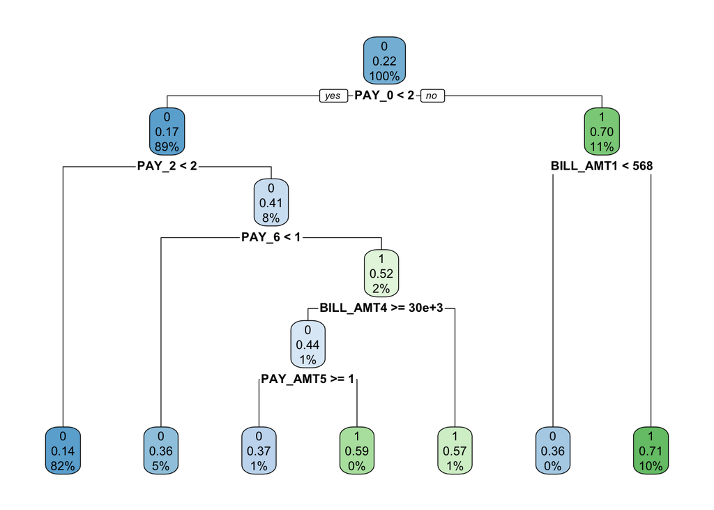

```r
# Plot CART model
rpart.plot(tran_tree)
```

```r
# Predict payment default for test data
tree_pred <- predict(tran_tree, newdata = test, type = "class")

# Evaluate the model
confusionMatrix(tree_pred, test$payment_default)$overall["Accuracy"]
```

```
##  Accuracy
## 0.8195355
```

```r
confusionMatrix(tree_pred, test$payment_default)$byClass["F1"]
```

```
##        F1
## 0.8915019
```

```r
################ Prune CART model
pruned_tree <- prune(tran_tree, cp = 0.01)
summary(pruned_tree)
```

```
## Call:
## rpart(formula = payment_default ~ ., data = train, method = "class",
##     cp = 0.002)
##   n= 21001
##
##          CP nsplit rel error    xerror       xstd
## 1 0.1872579      0 1.0000000 1.0000000 0.01294690
## 2 0.0100000      1 0.8127421 0.8127421 0.01197833
##
## Variable importance
## PAY_0 PAY_4 PAY_5 PAY_3 PAY_6 PAY_2
##    85     4     4     3     3     2
##
## Node number 1: 21001 observations,    complexity param=0.1872579
##   predicted class=0  expected loss=0.2212276  P(node) =1
##     class counts: 16355  4646
##    probabilities: 0.779 0.221
##   left son=2 (18793 obs) right son=3 (2208 obs)
##   Primary splits:
##       PAY_0 < 1.5 to the left,  improve=1117.0980, (0 missing)
##       PAY_2 < 1.5 to the left,  improve= 824.5682, (0 missing)
##       PAY_3 < 1.5 to the left,  improve= 623.5068, (0 missing)
##       PAY_4 < 0.5 to the left,  improve= 560.0111, (0 missing)
##       PAY_5 < 1   to the left,  improve= 522.6732, (0 missing)
##   Surrogate splits:
##       PAY_4 < 2.5 to the left,  agree=0.900, adj=0.044, (0 split)
##       PAY_5 < 2.5 to the left,  agree=0.899, adj=0.043, (0 split)
##       PAY_3 < 2.5 to the left,  agree=0.898, adj=0.033, (0 split)
##       PAY_6 < 2.5 to the left,  agree=0.898, adj=0.031, (0 split)
##       PAY_2 < 2.5 to the left,  agree=0.898, adj=0.028, (0 split)
##
## Node number 2: 18793 observations
##   predicted class=0  expected loss=0.1653275  P(node) =0.8948621
##     class counts: 15686  3107
##    probabilities: 0.835 0.165
##
## Node number 3: 2208 observations
##   predicted class=1  expected loss=0.3029891  P(node) =0.1051379
##     class counts:   669  1539
##    probabilities: 0.303 0.697
```

```r
printcp(pruned_tree)
```

```
##
## Classification tree:
## rpart(formula = payment_default ~ ., data = train, method = "class",
##     cp = 0.002)
##
## Variables actually used in tree construction:
## [1] PAY_0
##
## Root node error: 4646/21001 = 0.22123
##
## n= 21001
##
##        CP nsplit rel error  xerror     xstd
## 1 0.18726      0   1.00000 1.00000 0.012947
## 2 0.01000      1   0.81274 0.81274 0.011978
```

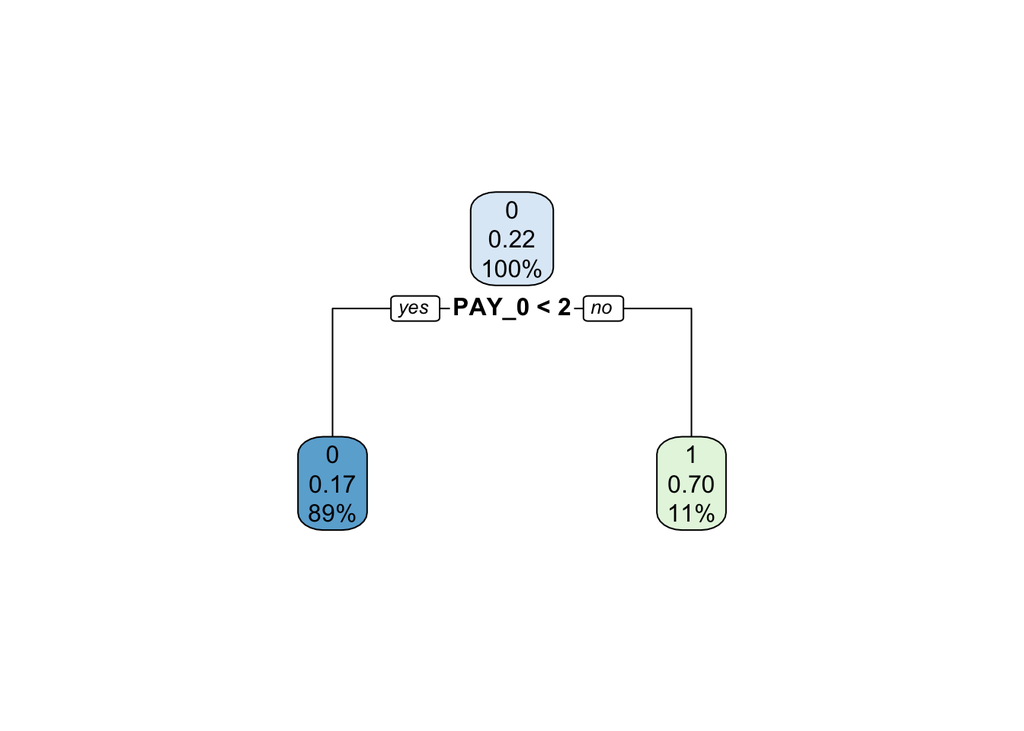

```r
# Plot pruned CART model
rpart.plot(pruned_tree)
```

```r
# Predict payment default for test data using pruned model
pruned_pred <- predict(pruned_tree, newdata = test, type = "class")

# Evaluate the pruned model
confusionMatrix(pruned_pred, test$payment_default)$overall["Accuracy"]
```

```
## Accuracy
## 0.818202
```

```r
confusionMatrix(pruned_pred, test$payment_default)$byClass["F1"]
```

```
##        F1
## 0.8915551
```

I’m going to first explain output based on the pruned CART tree. Accuracy is 0.818202, and F1 score is 0.8915551. According to the summary output and the plot, the tree depth is pruned to 1. “PAY_0” is the only variables actually used in tree construction; “PAY_0” is the root node, and the root node error is 0.22123, meaning that about 22% of the observations are misclassified by the initial tree. The plot is saying that if “PAY_0” is less than 2, the prediction would be class 0 (which means they will not default on their payment), and if “PAY_0” is greater than 2, the prediction would be class 1 (which means they will default on their payment).

Specifically, the left leaf node has the probability of class 0 is 15,686 / 18,793 = 0.84, and the probability of class 1 is 3,107 / 18,793 = 0.17. “89%” indicates the proportion of observations that belong to this particular node relative to the total number of observations in the tree. In this case, left leaf has 18,793 observations out of 21,001 total observations, so the proportion is about 89.5%. The right leaf node has the probability of class 0 as 0.30, and the probability of class 1 as 0.70.

For original CART tree, accuracy is 0.8195355, and F1 score is 0.8915019 According to the summary output and the plot, it appears that variables “PAY_0” has the highest importance as it’s the root node, and the root node error is also 0.22123. “PAY_2”, “PAY_5”, “PAY_3”, “PAY_4”, “PAY_6”’s importance are followed by “PAY_0”. Overall, the tree was constructed using 6 predictor variables: BILL_AMT1, BILL_AMT4, PAY_0, PAY_2, PAY_6, PAY_AMT5.

Based on the results from original CART tree and pruned CART tree, pruned CART model did not improve its performance significantly. Since the difference in performance between the original and pruned models is very small, it’s possible that the original model was not overfitting the training data significantly, and therefore pruning did not have a big impact on performance.

## 5.2 Random Forest

```r
# Fit the forest
tran_forest <- randomForest(payment_default ~ ., data = train, importance=TRUE)
print(tran_forest)
```

```
##
## Call:
##  randomForest(formula = payment_default ~ ., data = train, importance = TRUE)
##                Type of random forest: classification
##                      Number of trees: 500
## No. of variables tried at each split: 4
##
##         OOB estimate of  error rate: 18.11%
## Confusion matrix:
##       0    1 class.error
## 0 15495  860  0.05258331
## 1  2944 1702  0.63366337
```

```r
summary(tran_forest)
```

```
##                 Length Class  Mode
## call                4  -none- call
## type                1  -none- character
## predicted       21001  factor numeric
## err.rate         1500  -none- numeric
## confusion           6  -none- numeric
## votes           42002  matrix numeric
## oob.times       21001  -none- numeric
## classes             2  -none- character
## importance         92  -none- numeric
## importanceSD       69  -none- numeric
## localImportance     0  -none- NULL
## proximity           0  -none- NULL
## ntree               1  -none- numeric
## mtry                1  -none- numeric
## forest             14  -none- list
## y               21001  factor numeric
## test                0  -none- NULL
## inbag               0  -none- NULL
## terms               3  terms  call
```

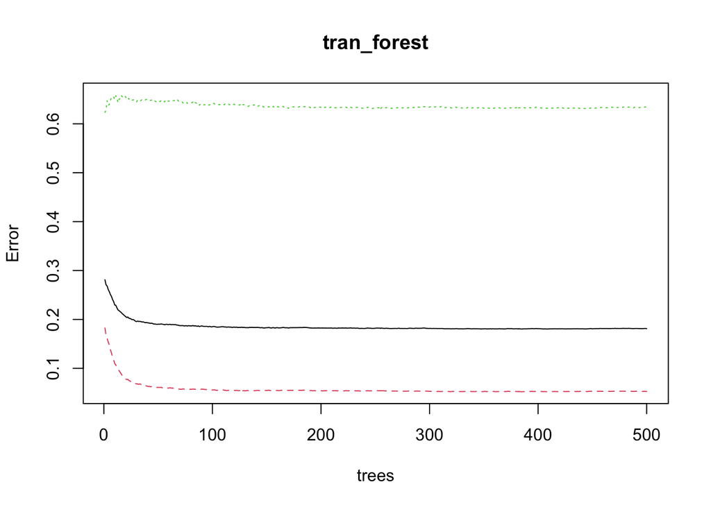

```r
# Plot the forest
plot(tran_forest)
```

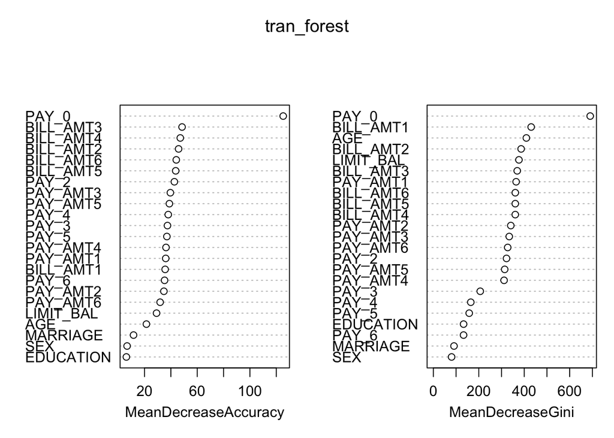

```r
# Visualize variable importance plot
varImpPlot(tran_forest)
```

```r
# Get variable importance table
importance_df <- as.data.frame(importance(tran_forest))
(importance_df <- importance_df[order(-importance_df$MeanDecreaseAccuracy),])
```

```
##                   0          1 MeanDecreaseAccuracy MeanDecreaseGini
## PAY_0     87.223675 86.4620957           125.248893        690.22914
## BILL_AMT3 42.861367 -6.1647686            48.495478        369.09866
## BILL_AMT4 40.180991 -2.9046821            47.133979        360.52735
## BILL_AMT2 39.186968 -4.4262855            45.857801        386.31088
## BILL_AMT6 35.404896  4.1549983            44.095183        360.62727
## BILL_AMT5 36.667580 -0.6304994            43.665811        360.57281
## PAY_2     34.752444  9.6013148            42.652267        321.94638
## PAY_AMT3  31.721582  6.4797846            39.611784        333.97452
## PAY_AMT5  33.929520 -2.0861127            38.871694        313.97657
## PAY_4     28.492437  9.2068569            37.999155        164.72019
## PAY_3     32.460727  7.6959763            37.410263        206.38579
## PAY_5     28.230850 11.7261461            36.969430        157.75723
## PAY_AMT4  28.887608  5.7736933            36.308782        311.17954
## PAY_AMT1  33.165025 -4.3831557            36.102130        364.29362
## BILL_AMT1 25.454561 16.5092029            35.657623        430.46278
## PAY_6     29.489776  7.4344671            35.204037        132.86359
## PAY_AMT2  29.751160  4.1622757            34.688387        340.86377
## PAY_AMT6  27.987175  7.1259096            31.848203        327.18998
## LIMIT_BAL 21.909529 18.8040842            29.122225        376.64179
## AGE       19.751941  6.3460347            21.438655        409.32625
## MARRIAGE  14.182049 -2.4092609            11.652986         90.82077
## SEX        5.424916  3.9347325             6.766164         80.25481
## EDUCATION  7.370314 -1.0196039             6.207801        132.98484
```

```r
# Evaluate the performance of the model on the testing data
forest_pred <- predict(tran_forest, newdata=test)
confusionMatrix(forest_pred, test$payment_default)$overall["Accuracy"]
```

```
##  Accuracy
## 0.8196466
```

```r
confusionMatrix(forest_pred, test$payment_default)$byClass["F1"]
```

```
##        F1
## 0.8912854
```

Random forest has accuracy of 0.8196466 and F1 score of 0.8912854. The number of trees is 500 in the model and number of variable tried at each split are 4. Classification error in predicting payment default as class 0 is 5.25%, as class 1 is 63%. The plot tells that error rate is stabilized with an increase in the number of trees. It seems like when trees=50, the error levels off and becomes stable, so maybe ~50 trees is also a good option to random forest. The OOB estimate of the error rate for the random forest model is 18.11%, meaning the proportion of OOB sample that were incorrectly classified is 18.11%.